# Task. Data visualization

Data and statistics with R Research Methods

Jüri Lillemets

2019-09-11

# Load and understand data

The data for the exercises is on the address below. If you open it in web browser, you should see that this data is formatted as *tsv* (tab-separated value). Thus, you need to use `read.table()` command and set `sep = '\t'` to have the function treat tabs as separators. Unlike `read.csv()`, `read.table()` does not treat the first line as a header by default, so you also need to specify this with `head = T`.

https://raw.githubusercontent.com/kwstat/agridat/master/data/lehner.soybeanmold.txt

```r
soybm <- read.table('https://raw.githubusercontent.com/kwstat/agridat/master/data/lehner.soybeanmold.txt',
                    sep = '\t', head = T)
```

Once you have managed to store the data as a `data.frame` object, take a look at it with `str()` command.

```r
str(soybm)
```

```
## 'data.frame':    382 obs. of  9 variables:
##  $ study    : Factor w/ 35 levels "S01","S02","S03",..: 9 9 9 9 9 9 9 9 9 9 ...
##  $ year     : int  2010 2010 2010 2010 2010 2010 2010 2010 2010 2010 ...
##  $ loc      : Factor w/ 14 levels "Agua Fria","Campo Verde",..: 1 1 1 1 1 1 1 1 1 1 ...
##  $ elev     : int  891 891 891 891 891 891 891 891 891 891 ...
##  $ region   : Factor w/ 2 levels "Northern","Southern": 1 1 1 1 1 1 1 1 1 1 ...
##  $ trt      : Factor w/ 13 levels "T01","T02","T03",..: 1 2 3 4 5 6 7 8 9 10 ...
##  $ yield    : num  3729 3739 3863 3904 4471 ...
##  $ mold     : num  37.7 11.6 33.5 1 5.6 1 3.7 0 1.1 0 ...
##  $ sclerotia: int  5092 6154 200 180 1123 641 1203 521 20 0 ...
```

This is data on yield, white mold, and sclerotia fungus for soybeans in Brazil. The variables are described as follows.

- `study`, study number
- `year`, year of harvest
- `loc`, location name
- `elev`, elevation
- `region`, region
- `trt`, treatment number
- `yield`, crop yield, kg/ha
- `mold`, white mold incidence, percent
- `sclerotia`, weight of sclerotia g/ha

Looking at the raw data may give you a better understanding of it. Use `head()` to see the first 10 rows.

```r
head(soybm, 10)
```

```
##    study year       loc elev   region trt yield mold sclerotia
## 1    S09 2010 Agua Fria  891 Northern T01  3729 37.7      5092
## 2    S09 2010 Agua Fria  891 Northern T02  3739 11.6      6154
## 3    S09 2010 Agua Fria  891 Northern T03  3863 33.5       200
## 4    S09 2010 Agua Fria  891 Northern T04  3904  1.0       180
## 5    S09 2010 Agua Fria  891 Northern T05  4471  5.6      1123
## 6    S09 2010 Agua Fria  891 Northern T06  4313  1.0       641
## 7    S09 2010 Agua Fria  891 Northern T07  4177  3.7      1203
## 8    S09 2010 Agua Fria  891 Northern T08  4001  0.0       521
## 9    S09 2010 Agua Fria  891 Northern T09  4090  1.1        20
## 10   S09 2010 Agua Fria  891 Northern T10  4254  0.0         0
```

# Take a look at the distribution of mold with histogram

Suppose we are interested in the values of mold. Use `hist()` function to plot a histogram of `mold`.

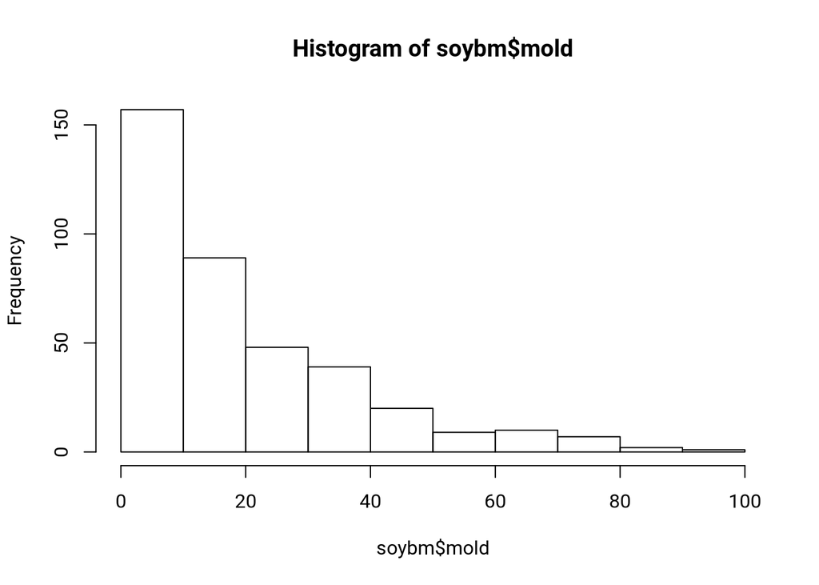

```r
hist(soybm$mold)
```

Now plot heights of the bars as probability densities by setting `freq = F`. Also, add some more breaks with `breaks = 30`. Then add density lines with `lines(density())` and try to bring out the line by adding some color with `col =`. See the output of `colors()` to see the color names recognized by R.

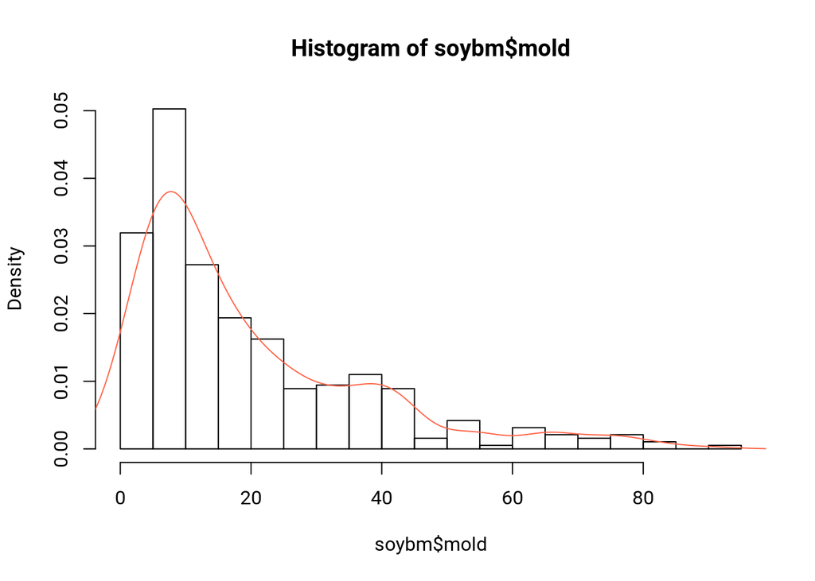

```r
hist(soybm$mold, breaks = 30, freq = F)
lines(density(soybm$mold), col = 'tomato')
```

# Plot the relationship between mold and yield

If we were interested whether higher yields cause mold or not, we could plot these two variables against each other. Do this with `plot()` function and create a scatterplot where `mold` is on y-axis and `yield` on x-axis.

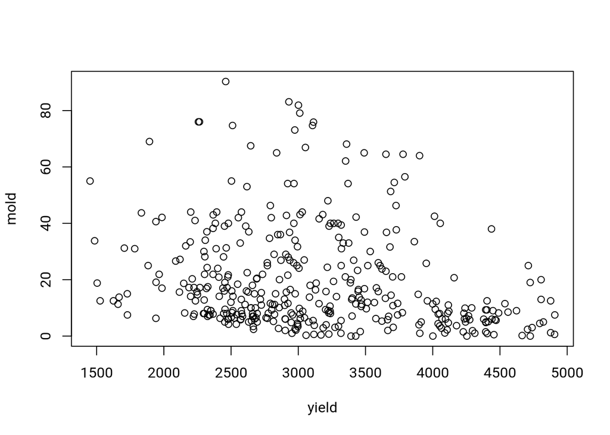

```r
plot(mold ~ yield, soybm)
```

Now also add a colored vertical line that indicates the mean value of yield. Use `abline(v = mean())` and add `col =` as an argument to `abline()`.

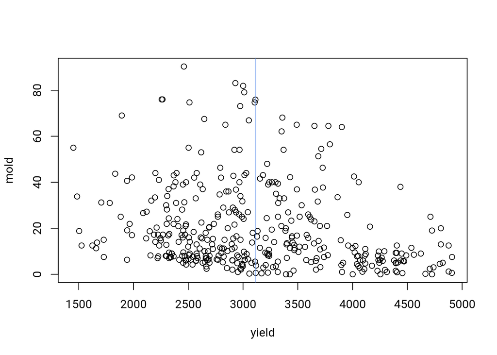

```r
plot(mold ~ yield, soybm)
abline(v = mean(soybm$yield), col = 'cornflowerblue')
```

# See the change over years

```r
aggr <- aggregate(mold ~ year, soybm, mean)
aggr <- aggr[order(aggr$year), ]
aggr
```

```
##   year     mold
## 1 2009 26.80769
## 2 2010 18.22743
## 3 2011 18.91109
## 4 2012 16.09923
```

Now you can use this data frame to plot `year` against `mold` as in the last plot. For time series, it is better to have a line, so set `type = 'l'`.

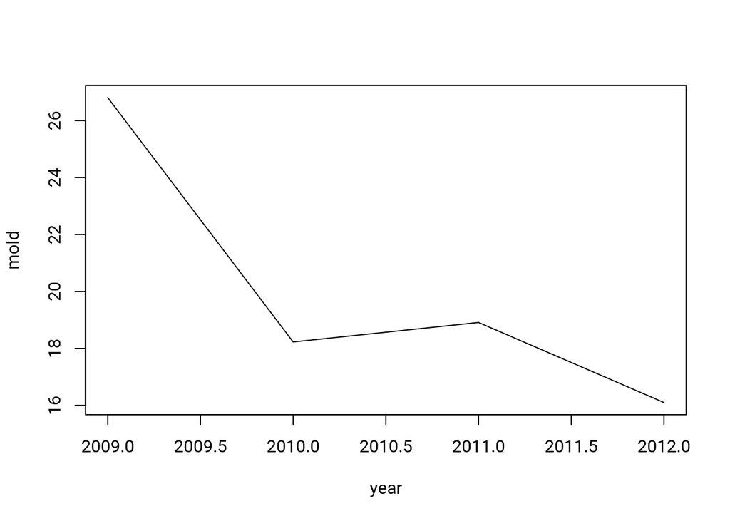

```r
plot(mold ~ year, aggr, type = 'l')
```

We can see that there has been a substatial decrease. Because the y-scale does not start from 0, this is misleading. Fix it by setting the limits of y-scale to 0 and maximum of `mold` with argument `ylim =`.

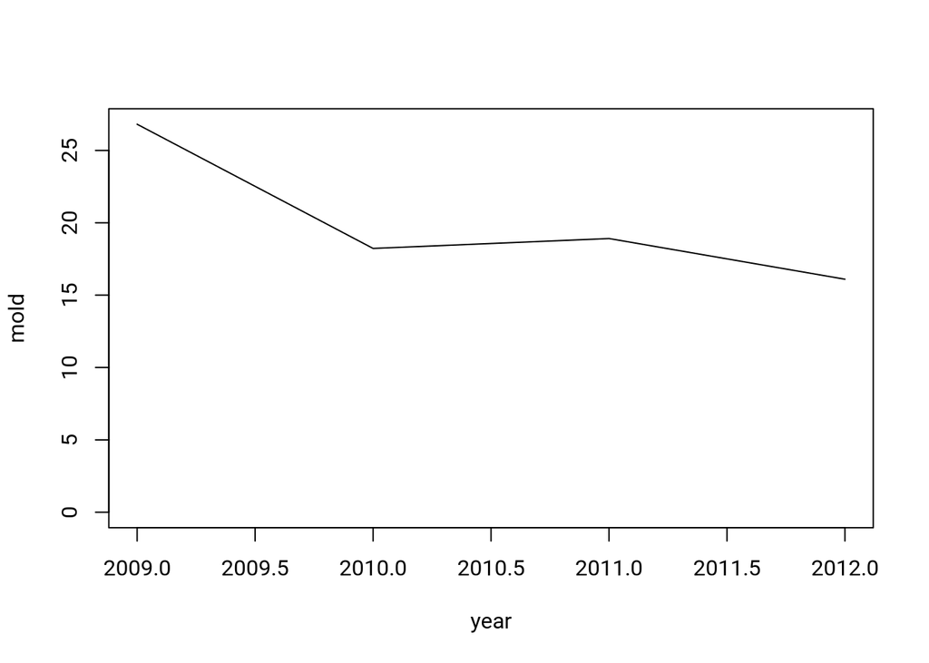

```r
plot(mold ~ year, aggr, type = 'l', ylim = c(0, max(aggr$mold)))
```

# Compare mean values between locations

Suppose we are now interested in how different are the mean mold incidences among locations. First you need to aggregate data to get mean vaues of `mold` by `loc`. Store the results in a data frame and then reorder it by `mold`.

```r
aggr <- aggregate(mold ~ loc, soybm, mean)
aggr <- aggr[order(aggr$mold), ]
aggr
```

```
##                           loc     mold
## 5           Marilandia do Sul  6.70000
## 8                  Nova Ponte  8.36800
## 1                   Agua Fria 11.51250
## 14                 Uberlandia 12.33125
## 10               Pilar do Sul 13.08095
## 12 Sao Miguel do Passa Quatro 16.73411
## 11               Ponta Grossa 16.95795
## 4                    Goianira 17.36364
## 3             Chapadao do Sul 17.45455
## 9                    Palmeira 18.65000
## 13                   Silvania 20.45455
## 2                 Campo Verde 21.38947
## 6               Maua da Serra 27.05882
## 7                  Montividiu 44.76136
```

Next, create a barplot of the aggregated values of `mold` and use `names.arg =` to add location names. Also, rotate the plot with `horiz = T` and make labels horizontal with `las = 1`.

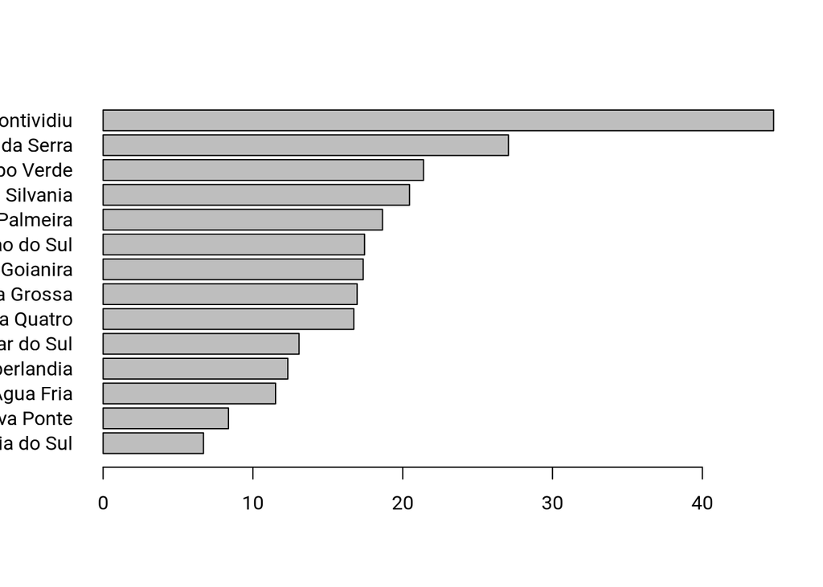

```r
barplot(aggr$mold, names.arg = aggr$loc, horiz = T, las = 1)
```

Since the location names are quite long, they are cropped. To fix this, widen the left margin to 10 lines and keep the rest of the margins at 2 lines by adjusting plot parameters with `par(mar = c(2,10,2,2))`. These numbers control the margins in following sequence: bottom, left, top, right.

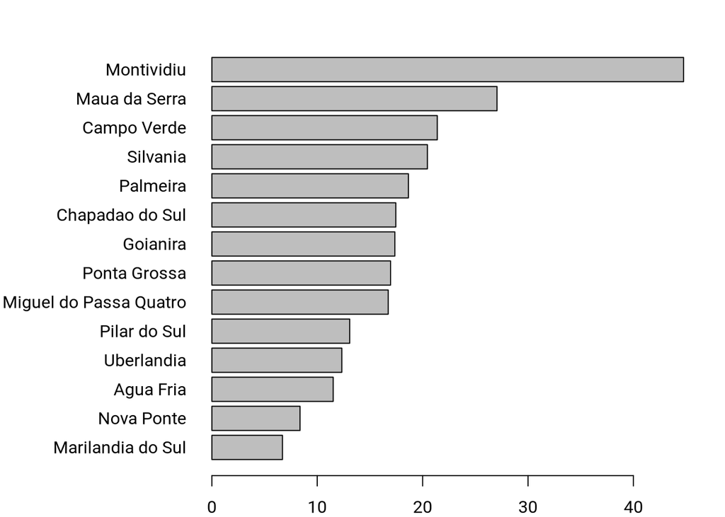

```r
par(mar = c(2,10,2,2))
barplot(aggr$mold, names.arg = aggr$loc, horiz = T, las = 1)
```

# Compare yields in different locations

Now, let’s see how yield compares between locations. Aggregate the data as in previous section, except this time aggregate the values of `yield` instead of `mold`.

```r
aggr <- aggregate(yield ~ loc, soybm, mean)
aggr <- aggr[order(aggr$yield), ]
aggr
```

```
##                           loc    yield
## 9                    Palmeira 1631.500
## 2                 Campo Verde 2176.895
## 6               Maua da Serra 2503.441
## 5           Marilandia do Sul 2796.200
## 8                  Nova Ponte 2843.920
## 14                 Uberlandia 2955.259
## 7                  Montividiu 3061.477
## 12 Sao Miguel do Passa Quatro 3066.500
## 3             Chapadao do Sul 3092.545
## 4                    Goianira 3300.909
## 13                   Silvania 3365.848
## 11               Ponta Grossa 3415.520
## 1                   Agua Fria 3839.094
## 10               Pilar do Sul 4441.000
```

This time use `dotchart()` to plot mean values of `yield` by `loc`.

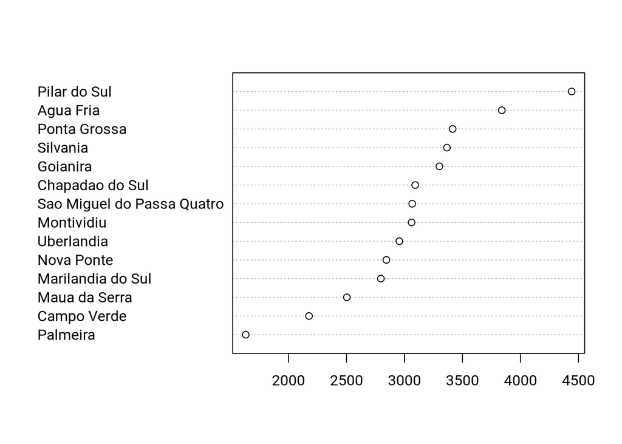

```r
dotchart(aggr$yield, aggr$loc)
```

# Get a better comparison by plotting quantiles

In previous sections we only looked at the difference in mean values. However, that is only part of the picture. A better comparison can be achieved by plotting quantile ranges of different locations side by side. Do this with `boxplot()` and use the formula `mold ~ loc`. Also, add `horizontal = T` and `las = 1` to rotate the plot.

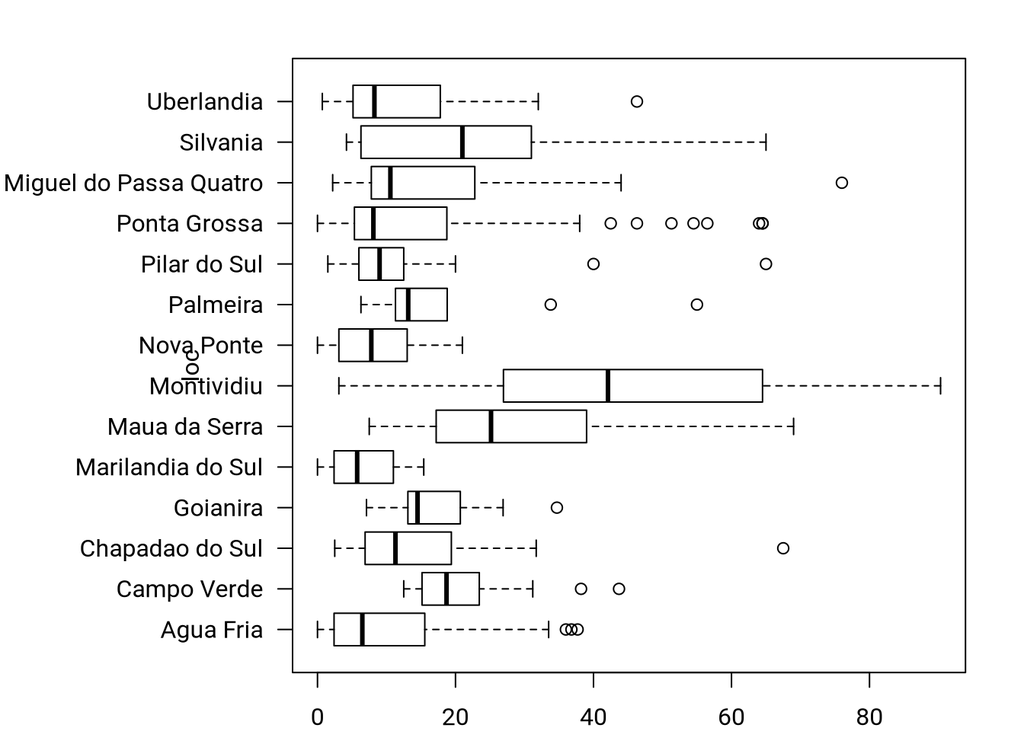

```r
boxplot(mold ~ loc, soybm, horizontal = T, las = 1)
```

# Create a publication ready plot

Suppose our last plot conveys some information we would like to publish. Thus, we need to add some elements to have a self-explanatory plot. Add the following elements:

- title, `main =`
- subtitle, `sub =`
- label for x-axis, `xlab =`
- label for y-axis, `ylab =`

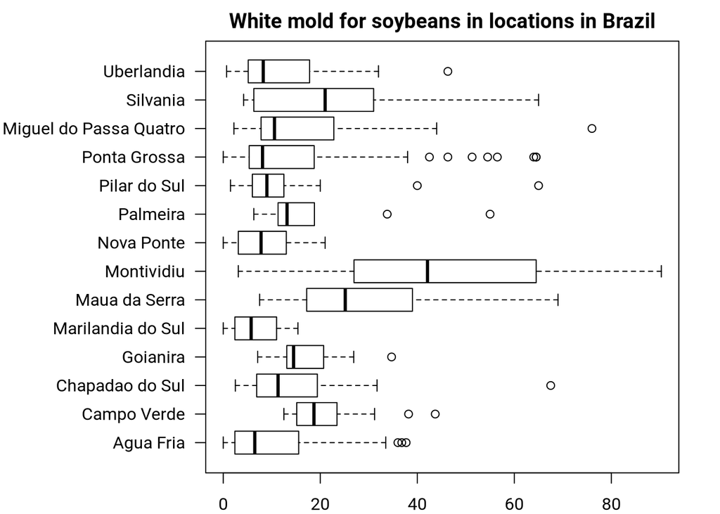

```r
boxplot(mold ~ loc, soybm, horizontal = T, las = 1,
        main = "White mold for soybeans in locations in Brazil",
        sub = "Lehner, M. S., Pethybridge, S. J., Meyer, M. C., & Del Ponte, E. M. (2016).",
        xlab = "White mold incidence, %",
        ylab = "")
```

Because we decreased the bottom margin, the x-axis label and subtitle are not visible. Change the bottom margin to 6 with `par(mar = c(6,10,2,2))`. Then draw the plot again.

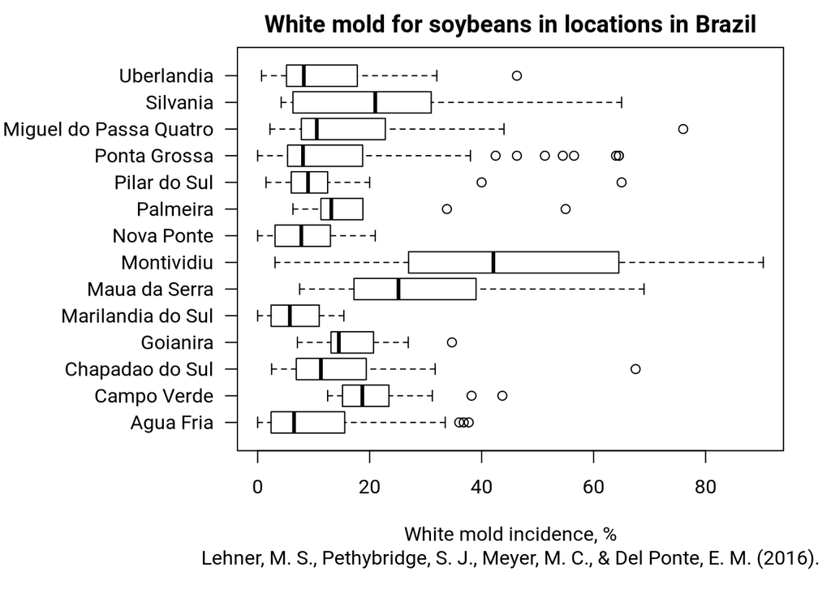

```r
par(mar = c(6,10,2,2))
boxplot(mold ~ loc, soybm, horizontal = T, las = 1,
        main = "White mold for soybeans in locations in Brazil",
        sub = "Lehner, M. S., Pethybridge, S. J., Meyer, M. C., & Del Ponte, E. M. (2016).",
        xlab = "White mold incidence, %",
        ylab = "")
```